# Saving Figures in RStudio

This is a simple tutorial on how to save a plot as an image file in R/RStudio.

# Creating a figure

Suppose I have loaded the salamander into a variable called `mander`.

```r
head(mander)
```

```
##        Date  Collector Year Season Site SVL Total_length    Sex
## 1  5-Sep-14 Sutherland 2014   Fall    A  36           72 female
## 2  4-Oct-14 Sutherland 2014   Fall    A  46           83 female
## 3  4-Oct-14 Sutherland 2014   Fall    A  42           89 female
## 4  4-Oct-14 Sutherland 2014   Fall    A  34           75 female
## 5  4-Oct-14 Sutherland 2014   Fall    A  37           80 female
## 6 18-Oct-14 Sutherland 2014   Fall    A  40           79 female
```

I’ll make a conditional boxplot of SVL by Site and Sex: (don’t worry if you don’t know what that means yet).

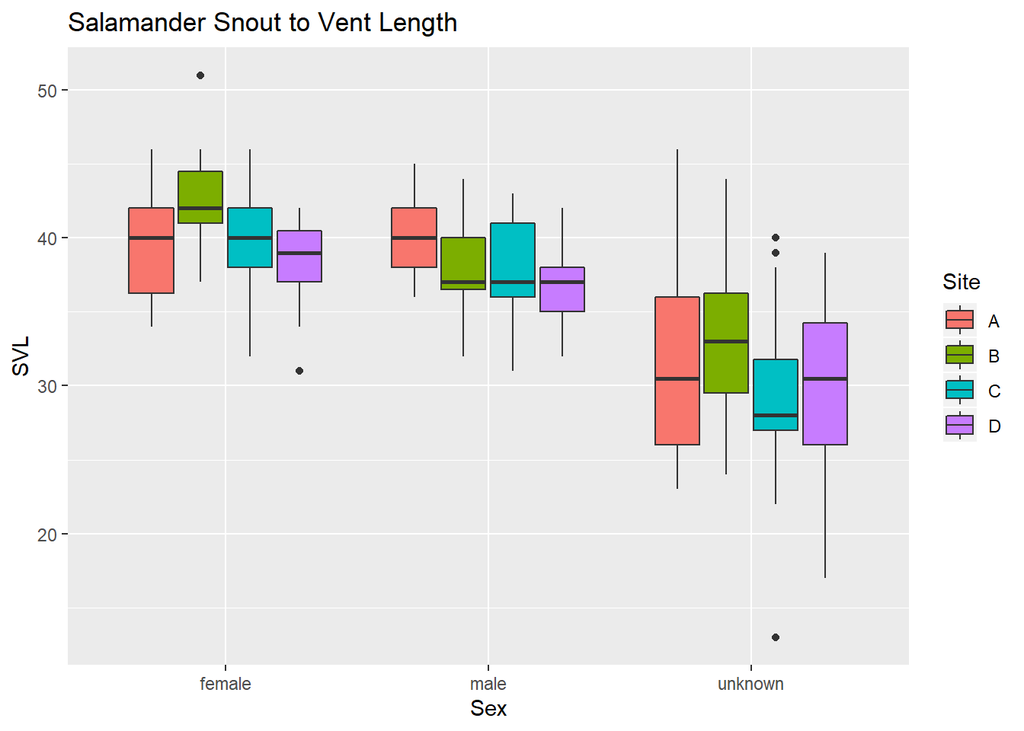

```r
ggplot(mander, aes(x = Sex, y = SVL, fill = Site)) +
  geom_boxplot() +
  ggtitle("Salamander Snout to Vent Length")
```

My RStudio session will look something like this:

[figure not shown]

# Save the figure method 1

Notice that above the plot there is a button that says *Export*. Click there and choose whether you want to save the image as a `.pdf` or `.png` file.

# Save the figure method 2

You can also save a figure directly using code in R. I prefer this method becuase you can more easily specify the options that you want to use for the image.

The image will be saved as the `filename` that you provide. The image will be saved in your **current working directory**.

The syntax is slightly different than what you’re used to. You have to use `png()` on the line before your plotting code. You have to place `dev.off()` on the line after your plotting code.

```r
# This tells R to start an image file:
png(filename = "salamander_boxplot.png")

# These lines create the plot.
# You won't see the plot in the RStudio plot window.
ggplot(mander, aes(x = Sex, y = SVL, fill = Site)) +
  geom_boxplot() +
  ggtitle("Salamander Snout to Vent Length")

# This tells R to finish creating the image file and save it.
dev.off()
```

`png()` has lots of options (see the help entry). For example, you can specify the height and width of the output image (in pixels).

I’ll now have a file called **salamander_boxplot.png** in my current working directory.

The best way to learn is to try it!